# Analysis Assignment – Pipeline Development

Samuel Perini

12/02/2021

The assignment for the Bioinformatician (Pipeline Development) position at SOPHiA GENETICS was composed of three main parts: **read coverage, variant calling and analytical performance**. The assignment was based on a targeted capture sequencing experiment in which paired-end reads were generated for one sample at a selected region of chromosome 19 of the human genome hg19.  
In this report, I first provide a brief background about capture sequencing technology with respect to the analysis of human genetic disorders. Then, for each of the three parts, I describe and interpret the respective results that were generated using a bioinformatics workflow for the analysis of clinical genomics (Fig. 1). The pipeline and the scripts have been uploaded to GitHub at this [link](https://github.com/sam0per/Bioinformatics_pipeline_development_task). The instructions on how to set it up and run it are provided at the same link.

### Background

Genetic mutations in protein coding genes are very likely to disrupt important biological functions and studying how these mutations appear and evolve is key for understanding disease-related traits in humans. Efficient strategies have been developed for selectively sequencing complete coding regions (i.e., ‘‘whole exome’’) and analysing thousands of genes simultaneously using next-generation sequencing techniques (Van Dijk et al. 2014). For instance, by sequencing the exome of a patient and comparing it with a normal reference sequence, variations in an individual’s DNA sequence can be identified and related back to the individual’s medical concerns in an effort to discover the cause of the medical disorder.  
Early comparative studies have focused on comparison of target intervals of various exome kits, and identified several important biases inherent to whole exome sequencing technology, such as coverage biases in regions with very high or low GC content (Barbitoff et al. 2020). One such region is the human chromosome 19 which includes gene density more than double the genome-wide average and 20 large tandemly clustered gene families. It also has the highest GC content of any chromosome, especially outside gene clusters (Grimwood et al. 2004). Genomic regions like chr19 have been shown to be highly variable within humans, providing an excellent resource for the identification of the genetic basis of common and rare diseases. In Next Generation Sequencing (NGS) studies, the term “coverage” describes the number of times that a nucleotide or base in the reference is covered by a high-quality aligned read. A reference can be a whole genome, a specific chromosome or targeted genomic regions and the number of reads that align to, or “cover” it is known as redundancy of coverage and also as the depth or the depth of coverage (Sims et al. 2014). Coverage has also been used to denote the breadth of coverage of a target genome, which is defined as the percentage of target bases that are sequenced a given number of times. For example, a genome sequencing study may sequence a genome to 30X average depth and achieve a 95% breadth of coverage of the reference genome at a minimum depth of ten reads.  
For this assignment, I was provided with three files: a BAM file containig paired reads that were aligned to a portion of chromosome 19 of the human genome hg19 using Bowtie 2, a BED file for the genomic regions of interest and a single-sample VCF file with a list of known single nucleotide variants (SNVs), and insertions and deletions (INDELs). The aim was to develop a bioinformatics pipeline starting from these three files and eventually analysing read coverage, calling variants and comparing the quality of the calls between ground truth and the pipeline (Fig .1).

[figure not shown]

Figure 1. Directed acyclic graph of the bioinformatics pipeline. Each circle is named with the rule or step of the analysis.

### (1) Read coverage

Then, I have restricted the coverage analysis to the target and off-target regions.  
On average, each base of the chr19 region was covered by 13 reads, meaning an average of 13X coverage (Fig. 2). The overal coverage was non-uniform (dispersion = 23) even after the removal of duplicate reads which was expected given the specific chatacteristics in GC content and gene dnsity of chr19 which are likely involved in coverage fluctuations due to biases connected with sample preparation, sequencing, genomic alignment and/or assembly.  
For single sample sequencing, which is the case of this assignment, an average of 30-35X coverage has been the standard minimum for generating a reliable variant call (Ajay et al. 2011; Sims et al. 2014).

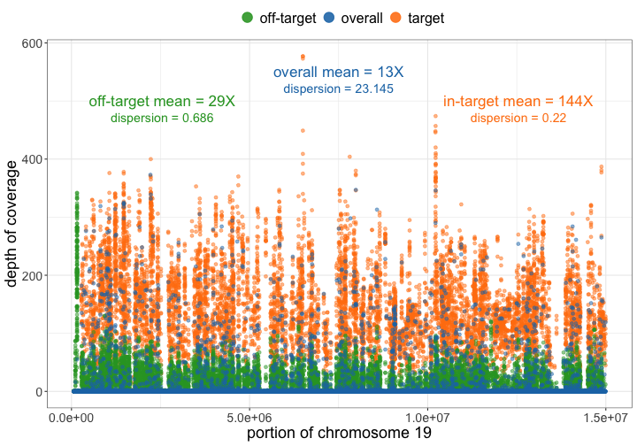

Figure 2. Read coverage for the selected region of chromosome 19, for the target and off-target region.

Ideally, a sample should show a uniform distribution of sequenced reads across the genome, i.e. all regions of the genome should have similar numbers of reads, regardless of their base-pair composition. In reality, the DNA polymerases used for PCR-based amplifications during the library preparation of the sequencing protocols prefer GC-rich regions. This will influence the outcome of the sequencing as there will be more reads for GC-rich regions just because of the DNA polymerase’s preference (Benjamini and Speed 2012).  
Using the software deepTools, the expected GC profile was calculated by counting the number of DNA fragments of a fixed size per GC fraction where GC fraction is defined as the number of G’s or C’s in a genome region of a given length. I have used as length the number of bases that were reported in the target region file (BED file). The result is basically a histogram depicting the frequency of DNA fragments or reads for each type of genome region with a GC fraction between 0 to 100 percent. The profile of the expected DNA fragment distribution is then compared to the observed GC profile, which is generated by counting the number of sequenced reads per GC fraction.

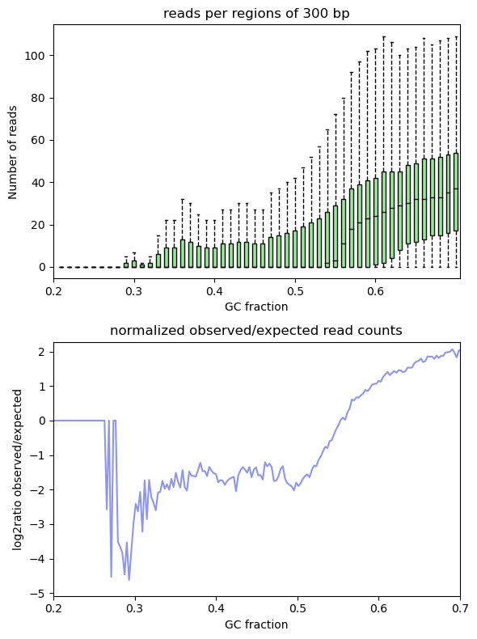

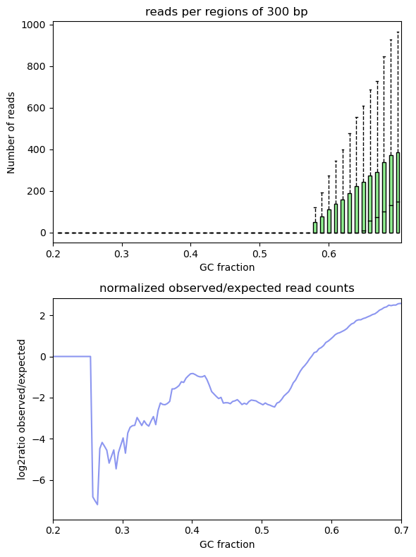

Figure 3. Off-target (left) and on-target (right) GC content using deepTools. Top: Boxplot depicting the observed number of reads for each type of genome region with a GC fraction between 0 to 100 percent. Bottom: log2ratio of the ratio between observed and expected number of reads with a given fraction of G’s or C’s bases.

### (2) Variant calling

Given the on-target mean coverage (144X), I have assumed that the original sequencing depth of the experiment was not aimed at detecting somatic mutations as it is often recommended to reach at least 250X to be able to find rare genetic changes. I have also performed a comparison with the variants collected in the COSMIC database and obtained very few matches (results not shown here). Hence, my decision to adopt an approach based on a germline variant calling using two of the most well-known softwares: GATK (McKenna et al. 2010) and SAMtools (Li et al. 2009). Default options were used for the calling and the same set of filters were then applied to both datasets.  
In literature it is usually assumed that the variation should be found in more than 1% of the population in order to be called a variant Such information is very useful for biomarker development since it describes the prevalence of the mutation in different populations.

### (3) Analytical performance

# References

Ajay, S. S., S. C. Parker, H. O. Abaan, K. V. Fajardo, and E. H. Margulies. 2011. Accurate and comprehensive sequencing of personal genomes. Genome Research 21:1498–505.

Barbitoff, Y. A., D. E. Polev, A. S. Glotov, E. A. Serebryakova, I. V. Shcherbakova, A. M. Kiselev, A. A. Kostareva, O. S. Glotov, and A. V. Predeus. 2020. Systematic dissection of biases in whole-exome and whole-genome sequencing reveals major determinants of coding sequence coverage. Scientific Reports 10:2057.

Benjamini, Y., and T. P. Speed. 2012. Summarizing and correcting the GC content bias in high-throughput sequencing. Nucleic Acids Research 40:e72–e72.

Broad Institute. 2018. Picard Tools. http://broadinstitute.github.io/picard/.

Grimwood, J., L. A. Gordon, A. Olsen, A. Terry, J. Schmutz, J. Lamerdin, U. Hellsten, D. Goodstein, O. Couronne, and M. Tran-Gyamfi. 2004. The DNA sequence and biology of human chromosome 19. Nature 428:529–535.

Guo, Y., Y. Dai, H. Yu, S. Zhao, D. C. Samuels, and Y. Shyr. 2017. Improvements and impacts of GRCh38 human reference on high throughput sequencing data analysis. Genomics 109:83–90.

Jiang, Y., Y. Jiang, S. Wang, Q. Zhang, and X. Ding. 2019. Optimal sequencing depth design for whole genome re-sequencing in pigs. BMC Bioinformatics 20:556.

Kozarewa, I., Z. Ning, M. A. Quail, M. J. Sanders, M. Berriman, and D. J. Turner. 2009. Amplification-free illumina sequencing-library preparation facilitates improved mapping and assembly of (g+c)-biased genomes. Nature Methods 6:291–5.

Kumaran, M., U. Subramanian, and B. Devarajan. 2019. Performance assessment of variant calling pipelines using human whole exome sequencing and simulated data. BMC Bioinformatics 20:342.

Lander, E. S., and M. S. Waterman. 1988. Genomic mapping by fingerprinting random clones: A mathematical analysis. Genomics 2:231–239.

Li, H., B. Handsaker, A. Wysoker, T. Fennell, J. Ruan, N. Homer, G. Marth, G. Abecasis, and R. Durbin. 2009. The sequence alignment/map format and SAMtools. Bioinformatics 25:2078–2079.

McKenna, A., M. Hanna, E. Banks, A. Sivachenko, K. Cibulskis, A. Kernytsky, K. Garimella, D. Altshuler, S. Gabriel, and M. Daly. 2010. The genome analysis toolkit: A MapReduce framework for analyzing next-generation DNA sequencing data. Genome Research 20:1297–1303.

R Core Team. 2020. R: A language and environment for statistical computing. R Foundation for Statistical Computing, Vienna, Austria.

Ramı́rez, F., D. P. Ryan, B. Grüning, V. Bhardwaj, F. Kilpert, A. S. Richter, S. Heyne, F. Dündar, and T. Manke. 2016. deepTools2: A next generation web server for deep-sequencing data analysis. Nucleic Acids Research 44:W160–W165.

Sims, D., I. Sudbery, N. E. Ilott, A. Heger, and C. P. Ponting. 2014. Sequencing depth and coverage: Key considerations in genomic analyses. Nature Review Genetics 15:121–32.

Van Dijk, E. L., H. Auger, Y. Jaszczyszyn, and C. Thermes. 2014. Ten years of next-generation sequencing technology. Trends in Genetics 30:418–426.